# 2 Probability and Statistics, Linear Regression

5 credits. Deadline: January 23/24, 11:59 pm.

## 1 Monte-Carlo Experiment. Play with different error-term distributions.

Let's do a Monte-Carlo experiment with linear regression.

### 1.1 Create random data

First create random data (x and eps), and y. Let $\epsilon \sim N(0,1)$.

```python
import numpy as np
import matplotlib.pyplot as plt

# Initialize random number generator
np.random.seed(123)

# True parameter values
alpha, sigma = 1, 1
beta = [1, 2.5]

# Size of dataset
size = 100

# Predictor variable
X1 = np.random.randn(size)
X2 = np.random.randn(size) * 0.2

# Simulate outcome variable
Y = alpha + beta[0]*X1 + beta[1]*X2 + np.random.randn(size)*sigma
```

[output not shown]

### 1.2 Visualize your data

Plot y as a function of x. Repeat the generation and plotting step and change the parameters until the dependency look reasonably clear but still somewhat noisy.

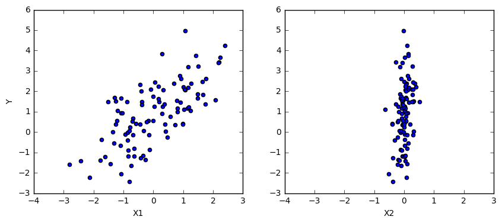

```python
%matplotlib inline

fig, axes = plt.subplots(1, 2, sharex=True, figsize=(10,4))
axes[0].scatter(X1, Y)
axes[1].scatter(X2, Y)
axes[0].set_ylabel('Y'); axes[0].set_xlabel('X1'); axes[1].set_xlabel('X2');
```

### 1.3 Estimate $\beta$

Estimate $\beta$ by the OLS formula (use the formula, not ready-made linear regression function). Explain your results. Note: include constant!

```python
from statsmodels.api import OLS
from pandas import DataFrame

x = DataFrame({'x1': X1, 'x2':X2})
x['b'] = 1 #adding constant

model = OLS(Y, x)
result = model.fit()
print result.summary()
```

```
                            OLS Regression Results
==============================================================================
Dep. Variable:                      y   R-squared:                       0.596
Model:                            OLS   Adj. R-squared:                  0.588
Method:                 Least Squares   F-statistic:                     71.59
Date:                Fri, 24 Feb 2017   Prob (F-statistic):           7.99e-20
Time:                        22:08:32   Log-Likelihood:                -138.58
No. Observations:                 100   AIC:                             283.2
Df Residuals:                      97   BIC:                             291.0
Df Model:                           2
Covariance Type:            nonrobust
==============================================================================
                 coef    std err          t      P>|t|      [95.0% Conf. Int.]
------------------------------------------------------------------------------
x1             0.9486      0.087     10.893      0.000         0.776     1.121
x2             2.6136      0.506      5.161      0.000         1.608     3.619
b              0.9067      0.098      9.226      0.000         0.712     1.102
==============================================================================
Omnibus:                        1.671   Durbin-Watson:                   1.841
Prob(Omnibus):                  0.434   Jarque-Bera (JB):                1.328
Skew:                           0.280   Prob(JB):                        0.515
Kurtosis:                       3.079   Cond. No.                         5.82
==============================================================================

Warnings:
[1] Standard Errors assume that the covariance matrix of the errors is correctly specified.
```

```python
print('Parameters: ', result.params)
print('Standard errors: ', result.bse)
```

```
('Parameters: ', x1    0.948576
x2    2.613561
b     0.906706
dtype: float64)
('Standard errors: ', x1    0.087080
x2    0.506401
b     0.098276
dtype: float64)
```

### 1.4 play with other "nice" distributions.

Create a new set of random data with another "well-behaved" distribution. Logistic and uniform distributions are good choices. Make x-y plot and estimate beta (remember the constant!) Explain the results.

### 1.5 Try a "bad" distribution

Now create new data with a "fat-tailed" distribution. You may pick Cauchy distribution for instance. Redo the plot and re-estimate $\beta$. Explain!

## 2 How Precise are your estimates?

### 2.1 Create unrelated $x$, $y$

Create similar random data: $x$, $y$, and $\epsilon$. However, this time create $y$ in a way that it does not depend on $x$. Use normal disturbances this time. Estimate $\beta$. How big is the $\hat\beta$ component that corresponds to $x$? Explain!

### 2.2 Compute the distribution of $\hat\beta$.

Repeat the exercise 1000 times. Plot the results on a histogram.

### 2.4 How common are large values?

How many time (out of the 1000 simulations) do the estimated $\beta$ exceed 1.96 times it's standard error? Which number do you expect based on theoretical grounds?